# Подготовка окружения

Перед началом работы рекомендуется создать отдельное окружение, чтобы устанавливаемые вами зависимости ставились не на уровне глобального интерпретатора Python, а на уровне локального окружения. Это полезная практика, которая нацелена на предотвращение ситуации, когда зависимости от разных проектов устанавливаются в одно окружение и начинают конфликтовать друг с другом

Если вы работаете через Anaconda, то ничего дополнительного делать не требуется

Если вы работает с чистым Python, то стоит предпринять следующее действия, обратившись к терминалу командной строки

(Здесь и далее команды приводятся для ОС MacOS)

1. Создать локальное окружение:  
   `python3 -m venv .venv`
2. Активировать локальное окружение:  
   `source .venv/bin/activate`
3. Обновить pip:  
   `pip install --upgrade pip`
4. Установить зависимости, используя файл requirements.txt:  
   `pip install -r requirements`

Все, ваше локальное окружение готово к работе

# Задания из вступительного тестирования

## Вопрос №1

Какой тип в Python реализует работу по принципу LIFO (Последний пришёл, первым уйдёшь)?

Множество (set)

Кортеж (tuple)

**Список (list)**

Куча (heap)

Давайте разберем каждый случай по отдельности

Множество в Python — это изменяемый, неупорядоченный набор уникальных элементов

Оно имеет ряд встроенных методов, из которых:

add помогает добавлять элемент в множество

remove помогает удалять элемент из множества

pop помогает получить случайных элемент из множества

Соответственно, нет двух методов, которые позволяли бы реализовать логику LIFO. Мы можем положить элемент в коллекцию, но не можем выбрать последний добавленный элемент, не зная значения этого элемента - метод `pop` возвращает случайный элемент коллекции, тогда как метод remove требует указания конкретного значения элемента

```python
[x for x in dir(set) if not x.startswith('_') and x != 'set']
```

```
['add',
 'clear',
 'copy',
 'difference',
 'difference_update',
 'discard',
 'intersection',
 'intersection_update',
 'isdisjoint',
 'issubset',
 'issuperset',
 'pop',
 'remove',
 'symmetric_difference',
 'symmetric_difference_update',
 'union',
 'update']
```

Кортеж в Python — это неизменяемая упорядоченная последовательность элементов. Исходя из определения, можно догадаться, что данная коллекция также не реализует интерфейс LIFO, потому что данная структура данных является неизменяемой. Мы можем лишь проинициализировать ее, но не можем добавлять или удалять элементы из существующего экземпляра класса

```python
[x for x in dir(tuple) if not x.startswith('_') and x != 'tuple']
```

```
['count', 'index']
```

Список в Python — это изменяемая упорядоченная последовательность элементов.

Он имеет ряд методов для управления своим содержимым:

append позволяет добавлять элемент в список

extend позволяет добавлять несколько элементов другого списка в целевой список

insert позволяет добавлять элемент на конкретную позицию внутри списка

pop позволяет удалить последний элемент из списка

remove позволяет удалять конкретный элемент из списка

Соответственно, с помощь методов `append` и `pop` реализуется логика работы с коллекцией по принципу LIFO

```python
[x for x in dir(list) if not x.startswith('_') and x != 'list']
```

```
['append',
 'clear',
 'copy',
 'count',
 'extend',
 'index',
 'insert',
 'pop',
 'remove',
 'reverse',
 'sort']
```

```python
arr = []

print(f"Инициализируем список: {arr}")

arr.append(1)

print(f"Добавили первый элемент: {arr}")

arr.append(2)

print(f"Добавили второй элемент: {arr}")

arr.pop()

print(f"Удалили последний добавленный элемент: {arr}")

arr.append(3)

print(f"Добавили еще один элемент: {arr}")

arr.pop()

print(f"Удалили последний добавленный элемент: {arr}")

arr.pop()

print(f"Еще раз удалил последний добавленный элемент: {arr}")
```

```
Инициализируем список: []
Добавили первый элемент: [1]
Добавили второй элемент: [1, 2]
Удалили последний добавленный элемент: [1]
Добавили еще один элемент: [1, 3]
Удалили последний добавленный элемент: [1]
Еще раз удалил последний добавленный элемент: []
```

Кучи в Python нет. В стандартной библиотеке Python для работы с кучей используется модуль `heapq`. Куча - это структура данных, реализующая приоритетную очередь, где всегда можно быстро получить минимальный (или максимальный) элемент. Соответственно, исходя из определения она работает не по принципу LIFO

### Ответ на вопрос 1: Список

## Вопрос №2

Выберите все основные принципы объектно-ориентированного программирования:

Алгоритмизация

**Наследование**

**Полиморфизм**

Воркфлоу

**Инкапсуляция**

Давайте разберем каждый случай по отдельности

Алгоритмизация не является принципом ООП. Алгоритмизация — это процесс разработки последовательности шагов для решения поставленной задачи

Наследование - это один из принципов ООП. Наследование — это механизм объектно-ориентированного программирования, позволяющий создавать новый класс на основе уже существующего. В примере ниже мы описываем два класса, первый из которых Animal имеет свой метод speak, а второй из которых Dog наследует все методы родительского класса Animal. Таким образом, экземпляры обоих классов имеют одинаковый метод, хотя для второго класса его никто вручную не прописывал

```python
class Animal:
    def speak(self):
        print("Животное издает звук")

class Dog(Animal):
    pass

animal = Animal()

animal.speak()

dog = Dog()

dog.speak()
```

```
Животное издает звук
Животное издает звук
```

Полиморфизм - это еще один из принципов ООП. Полиморфизм — это свойство объектно-ориентированного программирования, позволяющее использовать один и тот же интерфейс для разных типов объектов. В примере ниже для дочернего класса переопределяется повоедение в рамках метода speak. Таким образом, оба класса имеют метод speak, но их реализация отличается

```python
class Animal:
    def speak(self):
        print("Животное издает звук")

class Dog(Animal):
    def speak(self):
        print("Собака лает")

animal = Animal()

animal.speak()

dog = Dog()

dog.speak()
```

```
Животное издает звук
Собака лает
```

Воркфлоу не является принципом ООП. Воркфлоу — это последовательность шагов, задач или процессов, которые выполняются для достижения определённой цели или результата.

Инкапсуляция - это также один из принципов ООП. Инкапсуляция — это принцип объектно-ориентированного программирования, который заключается в объединении данных и методов, работающих с ними, внутри одного класса, а также в ограничении доступа к внутренним деталям реализации объекта. Это позволяет скрыть сложность и защищать данные от некорректного использования.

В Python инкапсуляция реализуется с помощью соглашений об именовании:

Обычные атрибуты (name) — общедоступные.

С одним подчёркиванием (_name) — для внутреннего использования.

С двумя подчёркиваниями (__name) — защищённые.

В примере ниже мы создаем класс Person, который имеет защищенный атрибут name, к которому не получится просто так достучаться. Чтобы его получить, надо будет воспользоваться вспомогательным методом get_name

```python
class Person:
    def __init__(self, name):
        self.__name = name

    def get_name(self):
        return self.__name

person = Person("Анна")

try:
    print(person.__name)
except AttributeError as e:
    print(f"Ошибка: {e}")

print(person.get_name())
```

```
Ошибка: 'Person' object has no attribute '__name'
Анна
```

### Ответ на вопрос 2: Наследование, Полиморфизм, Инкапсулция

## Вопрос №3

Как расширить область видимости переменной внутри функции?

**Использовать ключевое слово global**

Передать её как аргумент

Объявить её внутри цикла

Удалить её перед использованием

Давайте разберем каждый случай по отдельности

Суть проблемы. Если мы попробуем обратиться к переменной, которая определена вне функции - ошибки не возникнет. Но если мы попробуем с ней что-нибудь сделать, то примененные операции будут действовать только в рамках нашей функции. Вне функции значение переменной останется прежним

```python
var = 42

def my_function():
    var = 100
    print(f"Внутри функции: {var}")

print(f"До вызова функции: {var}")

my_function()

print(f"После вызова функции: {var}")
```

```
До вызова функции: 42
Внутри функции: 100
После вызова функции: 42
```

Использовать ключевое слово global. Такой вариант нам подходит. После использования ключевого слова global изменится область видимости при работе с указанной переменной. Примененные операции сохранят свое действие и по окончании выполнения функции

```python
var = 42

def my_function():
    global var
    var = 100
    print(f"Внутри функции: {var}")

print(f"До вызова функции: {var}")

my_function()

print(f"После вызова функции: {var}")
```

```
До вызова функции: 42
Внутри функции: 100
После вызова функции: 100
```

Передать её как аргумент. Это не поможет. Применяемые операции будут сохранять свое действие лишь внутри фукнции

```python
var = 42

def my_function(var):
    var = 100
    print(f"Внутри функции: {var}")

print(f"До вызова функции: {var}")

my_function(var)

print(f"После вызова функции: {var}")
```

```
До вызова функции: 42
Внутри функции: 100
После вызова функции: 42
```

Объявить её внутри цикла. Это не рекомендуется, так как может привести к путанице и ошибкам в коде. Лучше объявлять переменные вне циклов, чтобы они были доступны в нужной области видимости.

```python
for i in range(5):
    def inner_function():
        print(f"Внутри цикла: {i}")
    inner_function()
```

```
Внутри цикла: 0
Внутри цикла: 1
Внутри цикла: 2
Внутри цикла: 3
Внутри цикла: 4
```

Удалить её перед использованием. Подобная операция приведет к ошибке

```python
var = 42

def my_function():
    del var
    var = 100
    print(f"Внутри функции: {var}")

print(f"До вызова функции: {var}")

try:
    my_function()
except UnboundLocalError as e:
    print(f"Ошибка: {e}")

print(f"После вызова функции: {var}")
```

```
До вызова функции: 42
Ошибка: cannot access local variable 'var' where it is not associated with a value
После вызова функции: 42
```

### Ответ на вопрос 3: Использовать ключевое слово global

## Вопрос №4

Вам предоставлен набор данных о характеристиках качества воды и ее пригодности для питья.

water_potability.csv

Характеристики:

pH: pH воды (измеряется в единицах pH).

Hardness: Жесткость воды (измеряется в мг/л).

Solids: Общее количество растворенных твердых веществ в воде (измеряется в ppm).

Chloramines: Количество хлораминов в воде (измеряется в ppm).

Sulfate: Количество сульфатов в воде (измеряется в мг/л).

Conductivity: Проводимость воды (измеряется в мкСм/см).

Organic_carbon: Количество органического углерода в воде (измеряется в ppm).

Trihalomethanes: Количество тригалометанов в воде (измеряется в мкг/л).

Turbidity: Мутность воды (измеряется в NTU).

Potability: Пригодность воды (1 означает питьевую, 0 - непитьевую).

Найдите медианное значение общего количества растворенных твердых веществ для питьевой воды. Округлите ответ до 2 знаков после точки. Пример ответа: 123.45

```python
import pandas as pd
import numpy as np
```

```python
df_water = pd.read_csv('../data/water_potability.csv')
```

```python
df_water.head()
```

|  | ph | Hardness | Solids | Chloramines | Sulfate | Conductivity | Organic_carbon | Trihalomethanes | Turbidity | Potability |
| --- | --- | --- | --- | --- | --- | --- | --- | --- | --- | --- |
| 0 | NaN | 204.890455 | 20791.318981 | 7.300212 | 368.516441 | 564.308654 | 10.379783 | 86.990970 | 2.963135 | 0 |
| 1 | 3.716080 | 129.422921 | 18630.057858 | 6.635246 | NaN | 592.885359 | 15.180013 | 56.329076 | 4.500656 | 0 |
| 2 | 8.099124 | 224.236259 | 19909.541732 | 9.275884 | NaN | 418.606213 | 16.868637 | 66.420093 | 3.055934 | 0 |
| 3 | 8.316766 | 214.373394 | 22018.417441 | 8.059332 | 356.886136 | 363.266516 | 18.436524 | 100.341674 | 4.628771 | 0 |
| 4 | 9.092223 | 181.101509 | 17978.986339 | 6.546600 | 310.135738 | 398.410813 | 11.558279 | 31.997993 | 4.075075 | 0 |

```python
np.round(df_water[df_water['Potability'] == 1]['Solids'].median(), 2)
```

```
np.float64(21199.39)
```

### Ответ на вопрос 4: 21199.39

## Вопрос №5

Продолжаем работать с набором данных о качестве воды. Найдите количество выбросов для характеристики Trihalomethanes, используя ящик с усами (усы рассчитываются как 1.5 межквартильных размаха, границы усов не входят в выбросы).

[figure not shown]

```python
import seaborn as sns
```

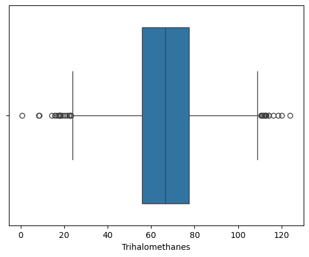

```python
sns.boxplot(data=df_water, x='Trihalomethanes')
```

```python
col = df_water['Trihalomethanes'].dropna()

q1 = col.quantile(0.25)
q3 = col.quantile(0.75)
iqr = q3 - q1

lb = q1 - 1.5 * iqr
ub = q3 + 1.5 * iqr

print(col[(col < lb) | (col > ub)].count())
```

```
33
```

### Ответ на вопрос 5: 33

## Вопрос №6

Что такое инкапсуляция в объектно-ориентированном программировании?

**Механизм, при котором данные и методы, работающие с ними, объединены в единую структуру.**

Процесс определения нового класса на основе существующего.

Способность объекта наследовать свойства и методы другого объекта.

Способность метода выполнять различные действия в зависимости от типа объекта, к которому он применяется.

Давайте разберем каждый случай по отдельности

Ранее мы уже рассмотрели, что такое инкапсуляция. Определение, данное в первом варианте ответа, также является валидным

Что касается остальных вариантов ответа, то второй и третий варианты описывают принцип наследования, тогда как четвертый вариант - полиморфизма

### Ответ на вопрос 6: Механизм, при котором данные и методы, работающие с ними, объединены в единую структуру

## Вопрос №7

Что означает понятие «итерация» в программировании?

**Процесс выполнения блока кода несколько раз.**

Процесс поиска и исправления ошибок в программе.

Процесс преобразования данных из одного формата в другой.

Процесс определения типов данных переменных.

Давайте разберем каждый случай по отдельности

Первый вариант ответа нам подходит. Это как раз является определением понятия "итерация". Пример выполнения кода через итерации приведен ниже

```python
for i in range(5):
    print(f"Итерация {i + 1}")
```

```
Итерация 1
Итерация 2
Итерация 3
Итерация 4
Итерация 5
```

Что касается других вариантов ответа. Процесс поиска и исправления ошибок в программе - это отладка или debugging. Процесс преобразования данных из одного формата в другой - это преобразование или conversion. Процесс определения типов данных переменных - это типизация или typing.

### Ответ на вопрос 7: Процесс выполнения блока кода несколько раз.

## Вопрос №8

Что означает инкремент переменной?

Уменьшение значения переменной на единицу.

**Увеличение значения переменной на единицу.**

Присваивание переменной нового значения.

Удаление переменной из памяти.

Давайте разберем каждый случай по отдельности

Уменьшение значения переменной на единицу - это декремент. Пример приведен ниже

```python
val = 42
print(f"Исходное значение: {val}")
val -= 1
print(f"Значение после декремента: {val}")
```

```
Исходное значение: 42
Значение после декремента: 41
```

Увеличение значения переменной на единицу - это как раз инкремент.

```python
val = 42
print(f"Исходное значение: {val}")
val += 1
print(f"Значение после инкремента: {val}")
```

```
Исходное значение: 42
Значение после инкремента: 43
```

Присваивание переменной нового значения - это просто приваивание.

```python
val = 42
print(f"Исходное значение: {val}")
val = 7
print(f"Значение после присваивания: {val}")
```

```
Исходное значение: 42
Значение после присваивания: 7
```

Удаление переменной из памяти - это просто удаление.

```python
val = 42
print(f"Исходное значение: {val}")
del val
print("Значение удалено, переменная больше не существует.")
try:
    print(val)
except NameError as e:
    print(f"Ошибка: {e}")
```

```
Исходное значение: 42
Значение удалено, переменная больше не существует.
Ошибка: name 'val' is not defined
```

### Ответ на вопрос 8: Увеличение значения переменной на единицу.

## Вопрос №9

Вам предоставлен набор данных о проданных машинах.

cars.csv

Характеристики:

year – год производства машины

make – бренд машины

model – модель машины

body – кузов машины

transmission – вид коробки передач

condition – состояние машины по шкале от 0 до 50

odometer – пробег машины в км

color – цвет кузова

interior – цвет интерьера

mmr – оценочная рыночная стоимость автомобиля

sellingprice – цена продажи автомобиля

Машин бренда Nissan какого года производства было продано меньше всего со следующими характеристиками: автоматическая (automatic) коробка передач, оценочная рыночная стоимость выше цены продажи автомобиля? В ответ выпишите год.

```python
df_cars = pd.read_csv('../data/cars.csv')
```

```python
df_cars.head()
```

|  | year | make | model | body | transmission | condition | odometer | color | interior | mmr | sellingprice |
| --- | --- | --- | --- | --- | --- | --- | --- | --- | --- | --- | --- |
| 0 | 2011 | Lexus | HS 250h | sedan | automatic | 35.0 | 42419.0 | silver | black | 17300.0 | 16500.0 |
| 1 | 2007 | Nissan | Sentra | Sedan | NaN | 19.0 | 91467.0 | blue | gray | 4500.0 | 4500.0 |
| 2 | 2002 | Pontiac | Sunfire | Coupe | automatic | 2.0 | 45237.0 | red | black | 1650.0 | 1300.0 |
| 3 | 2010 | Toyota | RAV4 | suv | automatic | 26.0 | 87653.0 | gray | beige | 10650.0 | 9800.0 |
| 4 | 2012 | Honda | Accord | Sedan | automatic | 37.0 | 34382.0 | black | black | 13900.0 | 14400.0 |

```python
set([x for x in df_cars['make'].dropna() if x.lower().startswith('n')])
```

```
{'Nissan', 'nissan'}
```

```python
df_cars['make'] = df_cars['make'].str.lower()
```

```python
df_cars[(df_cars['make'] == 'nissan') & (df_cars['transmission'] == 'automatic') & (df_cars['mmr'] > df_cars['sellingprice'])] \
    .groupby('year').size().sort_values(ascending=True).head(10)
```

```
year
1996     1
1995     2
1997     2
1999     2
1998     4
2000     4
2001     7
2002    13
2015    20
2003    23
dtype: int64
```

### Ответ на вопрос 9: 1996

## Вопрос №10

Продолжаем работать с набором данных о проданных машинах. Вычислите размах (разница между максимальным и минимальным значением) по модулю для характеристики "состояние машины по шкале от 0 до 50" для каждого бренда машины. У скольких брендов размах меньше 30?

```python
df_cars_condition = df_cars.groupby('make').agg({'condition': ['min', 'max']}).reset_index()
df_cars_condition.columns = ['make', 'min_condition', 'max_condition']
df_cars_condition['range_condition'] = df_cars_condition['max_condition'] - df_cars_condition['min_condition']
```

```python
df_cars_condition[df_cars_condition['range_condition'] < 30].reset_index(drop=True)
```

|  | make | min_condition | max_condition | range_condition |
| --- | --- | --- | --- | --- |
| 0 | bentley | 23.0 | 48.0 | 25.0 |
| 1 | dodge tk | 19.0 | 19.0 | 0.0 |
| 2 | fisker | 38.0 | 38.0 | 0.0 |
| 3 | geo | 1.0 | 1.0 | 0.0 |
| 4 | isuzu | 1.0 | 27.0 | 26.0 |
| 5 | landrover | 41.0 | 41.0 | 0.0 |
| 6 | maserati | 23.0 | 48.0 | 25.0 |
| 7 | plymouth | 19.0 | 19.0 | 0.0 |
| 8 | rolls-royce | 42.0 | 42.0 | 0.0 |

### Ответ на вопрос 10: 9